# Starting with data

Data Carpentry contributors and Klaus Schliep

### Learning Objectives

- Load external data from a .csv file into a data frame.
- Install and load packages.
- Describe what a data frame is.
- Summarize the contents of a data frame.
- Use indexing to subset specific portions of data frames.
- Describe what a factor is.
- Convert between strings and factors.
- Make easy plots
- t-test
- Reorder and rename factors.
- Change how character strings are handled in a data frame.
- Format dates.

## Loading the survey data

We are investigating the animal species diversity and weights found within plots at our study site. The dataset is stored as a comma separated value (CSV) file. Each row holds information for a single animal, and the columns represent:

| Column | Description |
| --- | --- |
| record_id | Unique id for the observation |
| month | month of observation |
| day | day of observation |
| year | year of observation |
| plot_id | ID of a particular experimental plot of land |
| species_id | 2-letter code |
| sex | sex of animal (“M”, “F”) |
| hindfoot_length | length of the hindfoot in mm |
| weight | weight of the animal in grams |
| genus | genus of animal |
| species | species of animal |
| taxon | e.g. Rodent, Reptile, Bird, Rabbit |
| plot_type | type of plot |

### Downloading the data

We created the folder that will store the downloaded data (`data_raw`) in the chapter [“00-about-R”]. If you skipped that part, it may be a good idea to have a look now, to make sure your working directory is set up properly.

We are going to use the R function `download.file()` to download the CSV file that contains the survey data from Figshare, and we will use `read_csv()` to load the content of the CSV file into R.

Inside the `download.file` command, the first entry is a character string with the source URL (“https://ndownloader.figshare.com/files/2292169”). This source URL downloads a CSV file from figshare. The text after the comma (“data_raw/portal_data_joined.csv”) is the destination of the file on your local machine. You’ll need to have a folder on your machine called “data_raw” where you’ll download the file. So this command downloads a file from Figshare, names it “portal_data_joined.csv” and adds it to a preexisting folder named “data_raw”.

```r
download.file(url = "https://ndownloader.figshare.com/files/2292169",
              destfile = "data_raw/portal_data_joined.csv")
```

### Reading the data into R

The file has now been downloaded to the destination you specified, but R has not yet loaded the data from the file into memory. To do this, we can use the `read_csv()` function from the **`tidyverse`** package.

Packages in R are basically sets of additional functions that let you do more stuff. The functions we’ve been using so far, like `round()`, `sqrt()`, or `c()` come built into R. Packages give you access to additional functions beyond base R. A similar function to `read_csv()` from the tidyverse package is `read.csv()` from base R. We don’t have time to cover their differences but notice that the exact spelling determines which function is used. Before you use a package for the first time you need to install it on your machine, and then you should import it in every subsequent R session when you need it.

To install the **`tidyverse`** package, we can type `install.packages("tidyverse")` straight into the console. In fact, it’s better to write this in the console than in our script for any package, as there’s no need to re-install packages every time we run the script. Then, to load the package type:

```r
## load the tidyverse packages, incl. dplyr
library(tidyverse)
```

Now we can use the functions from the **`tidyverse`** package. Let’s use `read_csv()` to read the data into a data frame (we will learn more about data frames later):

```r
surveys <- read_csv("data_raw/portal_data_joined.csv")
```

When you execute `read_csv` on a data file, it looks through the first 1000 rows of each column and guesses its data type. For example, in this dataset, `read_csv()` reads `weight` as `col_double` (a numeric data type), and `species` as `col_character`. You have the option to specify the data type for a column manually by using the `col_types` argument in `read_csv`.

### Note

`read_csv()` assumes that fields are delineated by commas. However, in several countries (like Austria or Germany), the comma is used as a decimal separator and the semicolon (;) is used as a field delineator. If you want to read in this type of files in R, you can use the `read_csv2()` function. It behaves like `read_csv()` but uses different parameters for the decimal and the field separators. There is also the `read_tsv()` for tab separated data files and `read_delim()` for less common formats. Check out the help for `read_csv()` by typing `?read_csv` to learn more.

In addition to the above versions of the csv format, you should develop the habits of looking at and recording some parameters of your csv files. For instance, the character encoding, control characters used for line ending, date format (if the date is not split into three variables), and the presence of unexpected [newlines](https://en.wikipedia.org/wiki/Newline) are important characteristics of your data files. Those parameters will ease up the import step of your data in R.

We can see the contents of the first few lines of the data by typing its name: `surveys`. By default, this will show you as many rows and columns of the data as fit on your screen. If you wanted the first 50 rows, you could type `print(surveys, n = 50)`

We can also extract the first few lines of this data using the function `head()`:

```r
head(surveys)
```

```
## # A tibble: 6 × 13
##   record_id month   day  year plot_id species_id sex   hindfoot_length weight
##       <dbl> <dbl> <dbl> <dbl>   <dbl> <chr>      <chr>           <dbl>  <dbl>
## 1         1     7    16  1977       2 NL         M                  32     NA
## 2        72     8    19  1977       2 NL         M                  31     NA
## 3       224     9    13  1977       2 NL         <NA>               NA     NA
## 4       266    10    16  1977       2 NL         <NA>               NA     NA
## 5       349    11    12  1977       2 NL         <NA>               NA     NA
## 6       363    11    12  1977       2 NL         <NA>               NA     NA
## # ℹ 4 more variables: genus <chr>, species <chr>, taxa <chr>, plot_type <chr>
```

Unlike the `print()` function, `head()` returns the extracted data. You could use it to assign the first 100 rows of `surveys` to an object using `surveys_sample <- head(surveys, 100)`. This can be useful if you want to try out complex computations on a subset of your data before you apply them to the whole data set. There is a similar function that lets you extract the last few lines of the data set. It is called (you might have guessed it) `tail()`.

To open the dataset in RStudio’s Data Viewer, use the `view()` function:

```r
view(surveys)
```

### Note

There are two functions for viewing which are case-sensitive. Using `view()` with a lowercase ‘v’ is part of tidyverse, whereas using `View()` with an uppercase ‘V’ is loaded through base R in the `utils` package.

## What are data frames?

When we loaded the data into R, it got stored as an object of class `tibble`, which is a special kind of data frame (the difference is not important for our purposes, but you can learn more about tibbles [here](https://tibble.tidyverse.org/)). Data frames are the *de facto* data structure for most tabular data, and what we use for statistics and plotting. Data frames can be created by hand, but most commonly they are generated by functions like `read_csv()`; in other words, when importing spreadsheets from your hard drive or the web.

A data frame is the representation of data in the format of a table where the columns are vectors that all have the same length. Because columns are vectors, each column must contain a single type of data (e.g., characters, integers, factors). For example, here is a figure depicting a data frame comprising a numeric, a character, and a logical vector.

[figure not shown]

We can see this also when inspecting the **str**ucture of a data frame with the function `str()`:

```r
str(surveys)
```

```
## spc_tbl_ [34,786 × 13] (S3: spec_tbl_df/tbl_df/tbl/data.frame)
##  $ record_id      : num [1:34786] 1 72 224 266 349 363 435 506 588 661 ...
##  $ month          : num [1:34786] 7 8 9 10 11 11 12 1 2 3 ...
##  $ day            : num [1:34786] 16 19 13 16 12 12 10 8 18 11 ...
##  $ year           : num [1:34786] 1977 1977 1977 1977 1977 ...
##  $ plot_id        : num [1:34786] 2 2 2 2 2 2 2 2 2 2 ...
##  $ species_id     : chr [1:34786] "NL" "NL" "NL" "NL" ...
##  $ sex            : chr [1:34786] "M" "M" NA NA ...
##  $ hindfoot_length: num [1:34786] 32 31 NA NA NA NA NA NA NA NA ...
##  $ weight         : num [1:34786] NA NA NA NA NA NA NA NA 218 NA ...
##  $ genus          : chr [1:34786] "Neotoma" "Neotoma" "Neotoma" "Neotoma" ...
##  $ species        : chr [1:34786] "albigula" "albigula" "albigula" "albigula" ...
##  $ taxa           : chr [1:34786] "Rodent" "Rodent" "Rodent" "Rodent" ...
##  $ plot_type      : chr [1:34786] "Control" "Control" "Control" "Control" ...
##  - attr(*, "spec")=
##   .. cols(
##   ..   record_id = col_double(),
##   ..   month = col_double(),
##   ..   day = col_double(),
##   ..   year = col_double(),
##   ..   plot_id = col_double(),
##   ..   species_id = col_character(),
##   ..   sex = col_character(),
##   ..   hindfoot_length = col_double(),
##   ..   weight = col_double(),
##   ..   genus = col_character(),
##   ..   species = col_character(),
##   ..   taxa = col_character(),
##   ..   plot_type = col_character()
##   .. )
##  - attr(*, "problems")=<externalptr>
```

## Inspecting data frames

We already saw how the functions `head()` and `str()` can be useful to check the content and the structure of a data frame. Here is a non-exhaustive list of functions to get a sense of the content/structure of the data. Let’s try them out!

- Size:
  - `dim(surveys)` - returns a vector with the number of rows in the first element, and the number of columns as the second element (the **dim**ensions of the object)
  - `nrow(surveys)` - returns the number of rows
  - `ncol(surveys)` - returns the number of columns
- Content:
  - `head(surveys)` - shows the first 6 rows
  - `tail(surveys)` - shows the last 6 rows
- Names:
  - `names(surveys)` - returns the column names (synonym of `colnames()` for `data.frame` objects)
  - `rownames(surveys)` - returns the row names
- Summary:
  - `str(surveys)` - structure of the object and information about the class, length and content of each column
  - `summary(surveys)` - summary statistics for each column

Note: most of these functions are “generic”, they can be used on other types of objects besides `data.frame`.

### Challenge

Based on the output of `str(surveys)`, can you answer the following questions?

- What is the class of the object `surveys`?
- How many rows and how many columns are in this object?

## Indexing and subsetting data frames

Our survey data frame has rows and columns (it has 2 dimensions), if we want to extract some specific data from it, we need to specify the “coordinates” we want from it. Row numbers come first, followed by column numbers. However, note that different ways of specifying these coordinates lead to results with different classes.

```r
# We can extract specific values by specifying row and column indices
# in the format:
# data_frame[row_index, column_index]
# For instance, to extract the first row and column from surveys:
surveys[1, 1]
```

```
## # A tibble: 1 × 1
##   record_id
##       <dbl>
## 1         1
```

```r
# First row, sixth column:
surveys[1, 6]
```

```
## # A tibble: 1 × 1
##   species_id
##   <chr>
## 1 NL
```

```r
# We can also use shortcuts to select a number of rows or columns at once
# To select all columns, leave the column index blank
# For instance, to select all columns for the first row:
surveys[1, ]
```

```
## # A tibble: 1 × 13
##   record_id month   day  year plot_id species_id sex   hindfoot_length weight
##       <dbl> <dbl> <dbl> <dbl>   <dbl> <chr>      <chr>           <dbl>  <dbl>
## 1         1     7    16  1977       2 NL         M                  32     NA
## # ℹ 4 more variables: genus <chr>, species <chr>, taxa <chr>, plot_type <chr>
```

```r
# The same shortcut works for rows --
# To select the first column across all rows:
surveys[, 1]
```

```
## # A tibble: 34,786 × 1
##    record_id
##        <dbl>
##  1         1
##  2        72
##  3       224
##  4       266
##  5       349
##  6       363
##  7       435
##  8       506
##  9       588
## 10       661
## # ℹ 34,776 more rows
```

```r
# An even shorter way to select first column across all rows:
surveys[1] # No comma!
```

```
## # A tibble: 34,786 × 1
##    record_id
##        <dbl>
##  1         1
##  2        72
##  3       224
##  4       266
##  5       349
##  6       363
##  7       435
##  8       506
##  9       588
## 10       661
## # ℹ 34,776 more rows
```

```r
# To select multiple rows or columns, use vectors!
# To select the first three rows of the 5th and 6th column
surveys[c(1, 2, 3), c(5, 6)]
```

```
## # A tibble: 3 × 2
##   plot_id species_id
##     <dbl> <chr>
## 1       2 NL
## 2       2 NL
## 3       2 NL
```

```r
# We can use the : operator to create those vectors for us:
surveys[1:3, 5:6]
```

```
## # A tibble: 3 × 2
##   plot_id species_id
##     <dbl> <chr>
## 1       2 NL
## 2       2 NL
## 3       2 NL
```

```r
# This is equivalent to head_surveys <- head(surveys)
head_surveys <- surveys[1:6, ]

# As we've seen, when working with tibbles
# subsetting with single square brackets ("[]") always returns a data frame.
# If you want a vector, use double square brackets ("[[]]")

# For instance, to get the first column as a vector:
# surveys[[1]]
# this is still too long to print here

# To get the first value in our data frame:
surveys[[1, 1]]
```

```
## [1] 1
```

`:` is a special function that creates numeric vectors of integers in increasing or decreasing order, test `1:10` and `10:1` for instance.

You can also exclude certain indices of a data frame using the “`-`” sign:

```r
surveys[, -1]                 # The whole data frame, except the first column
```

```
## # A tibble: 34,786 × 12
##    month   day  year plot_id species_id sex   hindfoot_length weight genus
##    <dbl> <dbl> <dbl>   <dbl> <chr>      <chr>           <dbl>  <dbl> <chr>
##  1     7    16  1977       2 NL         M                  32     NA Neotoma
##  2     8    19  1977       2 NL         M                  31     NA Neotoma
##  3     9    13  1977       2 NL         <NA>               NA     NA Neotoma
##  4    10    16  1977       2 NL         <NA>               NA     NA Neotoma
##  5    11    12  1977       2 NL         <NA>               NA     NA Neotoma
##  6    11    12  1977       2 NL         <NA>               NA     NA Neotoma
##  7    12    10  1977       2 NL         <NA>               NA     NA Neotoma
##  8     1     8  1978       2 NL         <NA>               NA     NA Neotoma
##  9     2    18  1978       2 NL         M                  NA    218 Neotoma
## 10     3    11  1978       2 NL         <NA>               NA     NA Neotoma
## # ℹ 34,776 more rows
## # ℹ 3 more variables: species <chr>, taxa <chr>, plot_type <chr>
```

```r
surveys[-(7:nrow(surveys)), ] # Equivalent to head(surveys)
```

```
## # A tibble: 6 × 13
##   record_id month   day  year plot_id species_id sex   hindfoot_length weight
##       <dbl> <dbl> <dbl> <dbl>   <dbl> <chr>      <chr>           <dbl>  <dbl>
## 1         1     7    16  1977       2 NL         M                  32     NA
## 2        72     8    19  1977       2 NL         M                  31     NA
## 3       224     9    13  1977       2 NL         <NA>               NA     NA
## 4       266    10    16  1977       2 NL         <NA>               NA     NA
## 5       349    11    12  1977       2 NL         <NA>               NA     NA
## 6       363    11    12  1977       2 NL         <NA>               NA     NA
## # ℹ 4 more variables: genus <chr>, species <chr>, taxa <chr>, plot_type <chr>
```

Data frames can be subset by calling indices (as shown previously), but also by calling their column names directly:

```r
# As before, using single brackets returns a data frame:
surveys["species_id"]
surveys[, "species_id"]

# Double brackets returns a vector:
surveys[["species_id"]]

# We can also use the $ operator with column names instead of double brackets
# This returns a vector:
surveys$species_id
```

In RStudio, you can use the autocompletion feature to get the full and correct names of the columns.

### Challenge

1. Create a `data.frame` (`surveys_200`) containing only the data in row 200 of the `surveys` dataset.
2. Notice how `nrow()` gave you the number of rows in a `data.frame`?
- Use that number to pull out just that last row from the `surveys` dataset.
- Compare that with what you see as the last row using `tail()` to make sure it’s meeting expectations.
- Pull out that last row using `nrow()` instead of the row number.
- Create a new data frame (`surveys_last`) from that last row.
3. Use `nrow()` to extract the row that is in the middle of the data frame. Store the content of this row in an object named `surveys_middle`.
4. Combine `nrow()` with the `-` notation above to reproduce the behavior of `head(surveys)`, keeping just the first through 6th rows of the surveys dataset.

## Factors

When we did `str(surveys)` we saw that several of the columns consist of integers. The columns `genus`, `species`, `sex`, `plot_type`, … however, are of the class `character`. Arguably, these columns contain categorical data, that is, they can only take on a limited number of values.

R has a special class for working with categorical data, called `factor`. Factors are very useful and actually contribute to making R particularly well suited to working with data. So we are going to spend a little time introducing them.

Once created, factors can only contain a pre-defined set of values, known as *levels*. Factors are stored as integers associated with labels and they can be ordered or unordered. While factors look (and often behave) like character vectors, they are actually treated as integer vectors by R. So you need to be very careful when treating them as strings.

When importing a data frame with `read_csv()`, the columns that contain text are not automatically coerced (=converted) into the `factor` data type, but once we have loaded the data we can do the conversion using the `factor()` function:

```r
surveys$sex <- factor(surveys$sex)
```

We can see that the conversion has worked by using the `summary()` function again. This produces a table with the counts for each factor level:

```r
summary(surveys$sex)
```

```
##     F     M  NA's
## 15690 17348  1748
```

By default, R always sorts levels in alphabetical order. For instance, if you have a factor with 2 levels:

```r
sex <- factor(c("male", "female", "female", "male"))
```

R will assign `1` to the level `"female"` and `2` to the level `"male"` (because `f` comes before `m`, even though the first element in this vector is `"male"`). You can see this by using the function `levels()` and you can find the number of levels using `nlevels()`:

```r
levels(sex)
```

```
## [1] "female" "male"
```

```r
nlevels(sex)
```

```
## [1] 2
```

Sometimes, the order of the factors does not matter, other times you might want to specify the order because it is meaningful (e.g., “low”, “medium”, “high”), it improves your visualization, or it is required by a particular type of analysis. Here, one way to reorder our levels in the `sex` vector would be:

```r
sex # current order
```

```
## [1] male   female female male
## Levels: female male
```

```r
sex <- factor(sex, levels = c("male", "female"))
sex # after re-ordering
```

```
## [1] male   female female male
## Levels: male female
```

In R’s memory, these factors are represented by integers (1, 2, 3), but are more informative than integers because factors are self describing: `"female"`, `"male"` is more descriptive than `1`, `2`. Which one is “male”? You wouldn’t be able to tell just from the integer data. Factors, on the other hand, have this information built in. It is particularly helpful when there are many levels (like the species names in our example dataset).

### Challenge

1. Change the columns `taxa` and `genus` in the `surveys` data frame into a factor.
2. Using the functions you learned before, can you find out…
- How many rabbits were observed?
- How many different genera are in the `genus` column?

### Converting factors

If you need to convert a factor to a character vector, you use `as.character(x)`.

```r
as.character(sex)
```

```
## [1] "male"   "female" "female" "male"
```

In some cases, you may have to convert factors where the levels appear as numbers (such as concentration levels or years) to a numeric vector. For instance, in one part of your analysis the years might need to be encoded as factors (e.g., comparing average weights across years) but in another part of your analysis they may need to be stored as numeric values (e.g., doing math operations on the years). This conversion from factor to numeric is a little trickier. The `as.numeric()` function returns the index values of the factor, not its levels, so it will result in an entirely new (and unwanted in this case) set of numbers. One method to avoid this is to convert factors to characters, and then to numbers.

Another method is to use the `levels()` function. Compare:

```r
year_fct <- factor(c(1990, 1983, 1977, 1998, 1990))
as.numeric(year_fct)               # Wrong! And there is no warning...
```

```
## [1] 3 2 1 4 3
```

```r
as.numeric(as.character(year_fct)) # Works...
```

```
## [1] 1990 1983 1977 1998 1990
```

```r
as.numeric(levels(year_fct))[year_fct]    # The recommended way.
```

```
## [1] 1990 1983 1977 1998 1990
```

Notice that in the `levels()` approach, three important steps occur:

- We obtain all the factor levels using `levels(year_fct)`
- We convert these levels to numeric values using `as.numeric(levels(year_fct))`
- We then access these numeric values using the underlying integers of the vector `year_fct` inside the square brackets

### Renaming factors

When your data is stored as a factor, you can use the `plot()` function to get a quick glance at the number of observations represented by each factor level. Let’s look at the number of males and females captured over the course of the experiment:

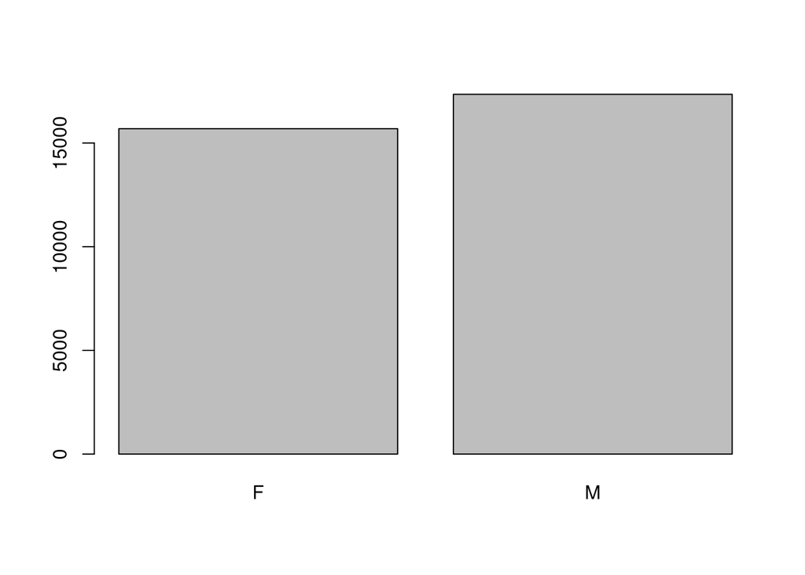

```r
## bar plot of the number of females and males captured during the experiment:
plot(surveys$sex)
```

However, as we saw when we used `summary(surveys$sex)`, there are about 1700 individuals for which the sex information hasn’t been recorded. To show them in the plot, we can turn the missing values into a factor level with the `addNA()` function. We will also have to give the new factor level a label. We are going to work with a copy of the `sex` column, so we’re not modifying the working copy of the data frame:

```r
sex <- surveys$sex
levels(sex)
```

```
## [1] "F" "M"
```

```r
sex <- addNA(sex)
levels(sex)
```

```
## [1] "F" "M" NA
```

```r
head(sex)
```

```
## [1] M    M    <NA> <NA> <NA> <NA>
## Levels: F M <NA>
```

```r
levels(sex)[3] <- "undetermined"
levels(sex)
```

```
## [1] "F"            "M"            "undetermined"
```

```r
head(sex)
```

```
## [1] M            M            undetermined undetermined undetermined
## [6] undetermined
## Levels: F M undetermined
```

Now we can plot the data again, using `plot(sex)`.

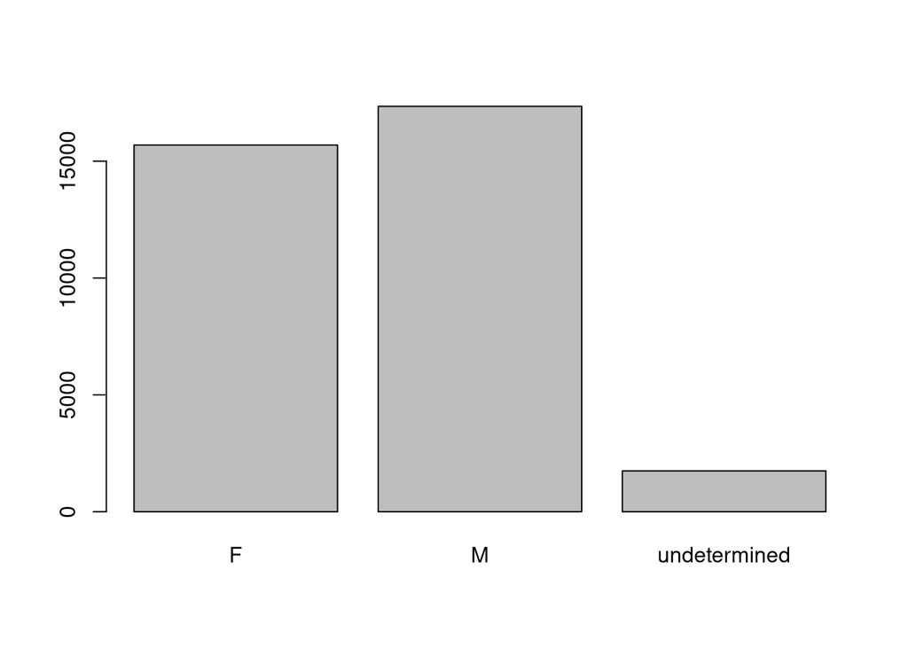

### Challenge

- Rename “F” and “M” to “female” and “male” respectively.
- Now that we have renamed the factor level to “undetermined”, can you recreate the barplot such that “undetermined” is first (before “female”)?

### Challenge

1. We have seen how data frames are created when using `read_csv()`, but they can also be created by hand with the `data.frame()` function. There are a few mistakes in this hand-crafted `data.frame`. Can you spot and fix them? Don’t hesitate to experiment!

```r
animal_data <- data.frame(
          animal = c(dog, cat, sea cucumber, sea urchin),
          feel = c("furry", "squishy", "spiny"),
          weight = c(45, 8 1.1, 0.8)
          )
```

2. Can you predict the class for each of the columns in the following example? Check your guesses using `str(country_climate)`:
- Are they what you expected? Why? Why not?
- What would you need to change to ensure that each column had the accurate data type?

```r
country_climate <- data.frame(
       country = c("Canada", "Panama", "South Africa", "Australia"),
       climate = c("cold", "hot", "temperate", "hot/temperate"),
       temperature = c(10, 30, 18, "15"),
       northern_hemisphere = c(TRUE, TRUE, FALSE, "FALSE"),
       has_kangaroo = c(FALSE, FALSE, FALSE, 1)
       )
```

The automatic conversion of data type is sometimes a blessing, sometimes an annoyance. Be aware that it exists, learn the rules, and double check that data you import in R are of the correct type within your data frame. If not, use it to your advantage to detect mistakes that might have been introduced during data entry (for instance, a letter in a column that should only contain numbers).

Learn more in this [RStudio tutorial](https://support.rstudio.com/hc/en-us/articles/218611977-Importing-Data-with-RStudio)

## Exploratory data analysis

## Measurement scales

We usually distinguish measurements into ”qualitative” (nominal) or ”quantitative” variables.

| Scale | Mathematical operators | Example |
| --- | --- | --- |
| Nominal | $=$, $\ne$ | Archaea, Bacteria, Eukarya |
| Ordinal | >, < | exam grades |
| Interval | + , - | temperature in Celsius |
| Ratio | * , / | temperature in Kelvin |

Nominal data will usually coded as factors.

## Mode, median & mean

- **mode:** the mode of a set of data values is the value that appears most often.
- **median:** the median is the value separating the higher half of a data sample, a population, or a probability distribution, from the lower half.
- **mean:** population mean and expected value are used synonymous to refer to one measure of the central tendency of a probability distribution or of the random variable. For discrete variables it is given by the following product: $\mu =\sum xP(x)$

The mode is defined on all scales, the median needs at least an ordinal scale, and the mean is only defined on interval or ratio scale.

Unfortunately there is no build in function coming with R. But we can write it ourself

```
getmode <- function(v) {
   uniqv <- unique(v)
   uniqv[which.max(tabulate(match(v, uniqv)))]
}
```

## Plotting data

Now let’s make sure that we have transformed discrete variables into factors:

```r
surveys <- read_csv("data_raw/portal_data_joined.csv")
surveys <- na.omit(surveys)
surveys$taxa <- factor(surveys$taxa)
surveys$genus <- factor(surveys$genus)
surveys$sex <- factor(surveys$sex)
surveys$species <- factor(surveys$species)
summary(surveys)
```

```
##    record_id         month             day             year
##  Min.   :   63   Min.   : 1.000   Min.   : 1.00   Min.   :1977
##  1st Qu.: 9882   1st Qu.: 4.000   1st Qu.:10.00   1st Qu.:1985
##  Median :18658   Median : 7.000   Median :16.00   Median :1991
##  Mean   :18475   Mean   : 6.548   Mean   :16.17   Mean   :1991
##  3rd Qu.:27132   3rd Qu.:10.000   3rd Qu.:23.00   3rd Qu.:1997
##  Max.   :35548   Max.   :12.000   Max.   :31.00   Max.   :2002
##
##     plot_id       species_id        sex       hindfoot_length     weight
##  Min.   : 1.00   Length:30676       F:14584   Min.   : 2.00   Min.   :  4.00
##  1st Qu.: 5.00   Class :character   M:16092   1st Qu.:21.00   1st Qu.: 20.00
##  Median :11.00   Mode  :character             Median :31.00   Median : 36.00
##  Mean   :11.22                                Mean   :29.21   Mean   : 41.79
##  3rd Qu.:17.00                                3rd Qu.:36.00   3rd Qu.: 47.00
##  Max.   :24.00                                Max.   :64.00   Max.   :280.00
##
##              genus               species         taxa        plot_type
##  Dipodomys      :14540   merriami    :9727   Rodent:30676   Length:30676
##  Chaetodipus    : 5781   penicillatus:2969                  Class :character
##  Onychomys      : 2991   baileyi     :2803                  Mode  :character
##  Reithrodontomys: 2500   ordii       :2790
##  Peromyscus     : 2068   megalotis   :2417
##  Perognathus    : 1500   torridus    :2081
##  (Other)        : 1296   (Other)     :7889
```

We can see that now we have less genera, as many had missing values.

Now explore the data a bit our data. The plot function is generic. This mean depending on the class of the input the output might differ.

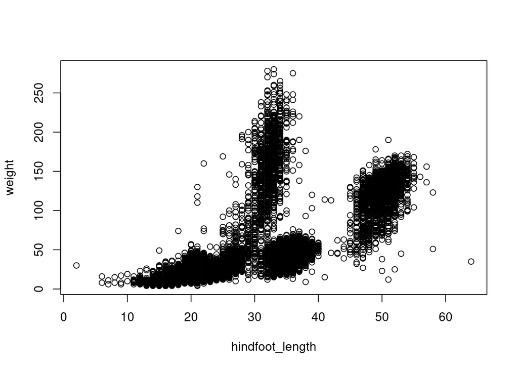

```r
plot(weight ~ hindfoot_length, data=surveys)
```

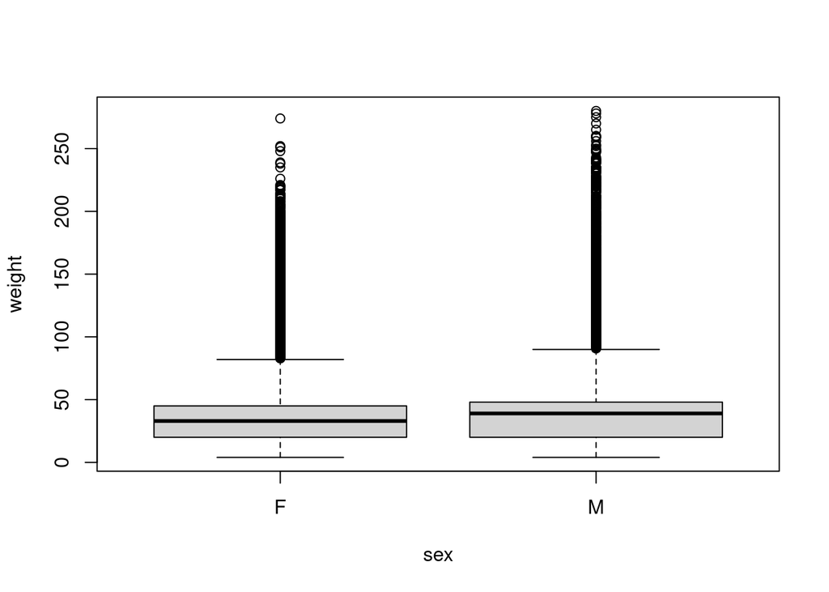

```r
plot(weight ~ sex, data=surveys)
```

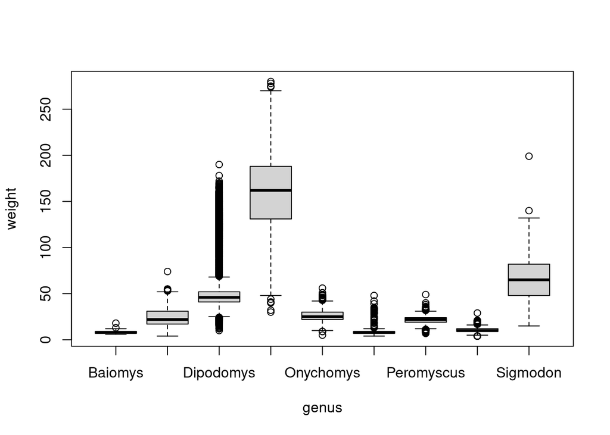

```r
plot(weight ~ genus, data=surveys)
```

With two continuous variables a scatter plot, and with a continuous and a discrete variable we get a box plot.

```r
(n <- nlevels(surveys$genus)) # number of genera
```

```
## [1] 9
```

```r
(lev <- levels(surveys$genus)) # different genera
```

```
## [1] "Baiomys"         "Chaetodipus"     "Dipodomys"       "Neotoma"
## [5] "Onychomys"       "Perognathus"     "Peromyscus"      "Reithrodontomys"
## [9] "Sigmodon"
```

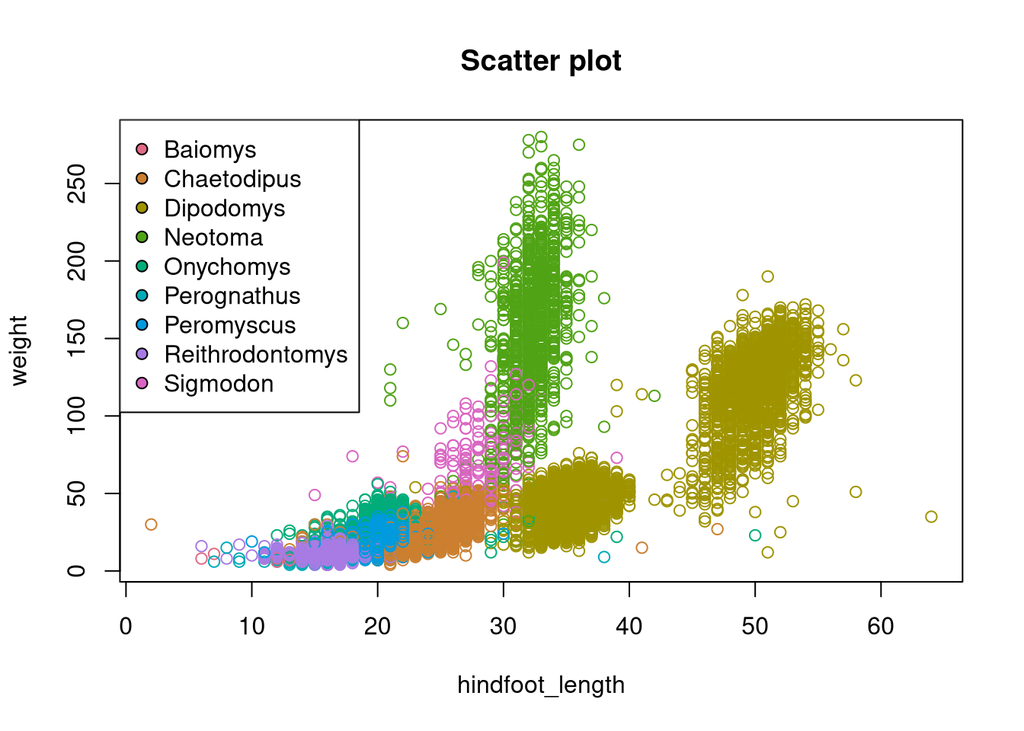

```r
col_vec <- hcl.colors(n, palette = "Dark 3")
names(col_vec) <- lev
plot(weight ~ hindfoot_length, data=surveys,
     col=col_vec[genus], main="Scatter plot")
legend("topleft", legend=lev, pch=21, pt.bg=col_vec[lev])
```

While the boxplot for the variable “sex” looks pretty much ok, we can improve the second boxplot. We will plot the boxes horizontal, add some space in the outer margins, to have enough space to add the labels (horizontal).

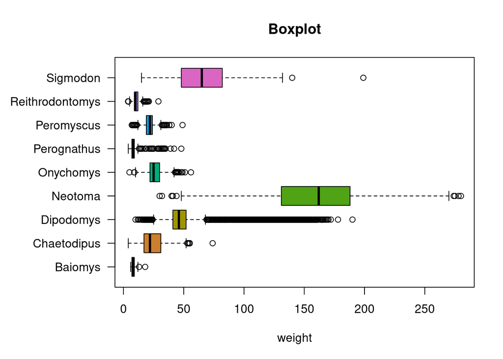

```r
op <- par(mar=c(5,8,4,2)) # increase left margin
plot(weight ~ genus, data=surveys, horizontal=TRUE, las=1,
     col=col_vec[lev], main="Boxplot", xlab="")
```

```r
par(op) # clean up, use old margins
```

Variation, getting really fancy. We use ridge plots instead of boxplots. these plots were formerly called joy plots named after the band joy division had an album cover with these plots.

```r
# install package if necessary
if(!require("ggridges"))install.packages("ggridges")
```

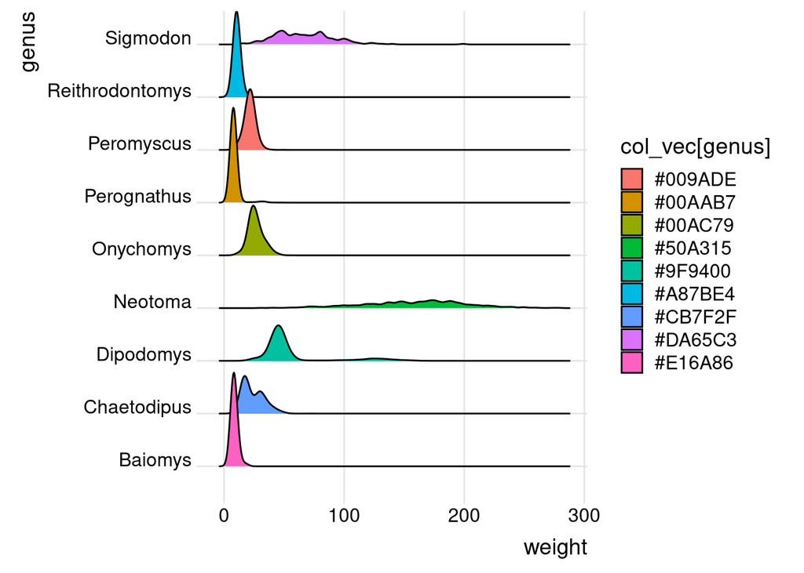

```r
library(ggplot2)
library(ggridges)

ggplot(surveys, aes(x = weight, y = genus, fill = col_vec[genus])) +
  geom_density_ridges() +
  theme_ridges()
```

A nice overview of the many plots possible with R can be found on the page https://r-graph-gallery.com/.

## Student’s t-test

First, we need to talk about **statistical hypothesis testing**. Two hypotheses should be described upon designing an experiment.

- The **NULL hypothesis H0**: that there is NO difference, for example, of means of weight between two populations of subjects.
- The **alternative hypothesis H1**: there is difference.

[figure not shown]

Second, we need to talk about the **statistical significance** of the results of the statistical test. For that, the **significance level**, denoted as $\alpha$, is defined.

The **significance level** is the probability to **reject the null hypothesis when it is assumed to be true**, i.e. concluding that the observed difference of means is the result of a real effect, while in reality it is not. The significance level of 0.05 indicates a **5% risk of concluding that a difference exists when there is no actual difference**.

Once the hypothesis are drawn and the significance level set, we perform a statistical test and we obtain a p-value.

If the p-value is **below the significance level** (for example, 0.05), we can reject the null hypothesis in favor of the alternative hypothesis, i.e. we conclude that the **observed difference is the result of a real effect**.

If the p-value is greater than the significance level we cannot the conclude that there is no difference!!!

Now lets test if there are any sex differences for the weight considering all data.

```r
t.test(weight ~ sex, data=surveys)
```

```
##
##  Welch Two Sample t-test
##
## data:  weight by sex
## t = -1.4996, df = 30195, p-value = 0.1337
## alternative hypothesis: true difference in means between group F and group M is not equal to 0
## 95 percent confidence interval:
##  -1.4128861  0.1880436
## sample estimates:
## mean in group F mean in group M
##        41.47010        42.08253
```

```r
wilcox.test(weight ~ sex, data=surveys)
```

```
##
##  Wilcoxon rank sum test with continuity correction
##
## data:  weight by sex
## W = 109931752, p-value < 2.2e-16
## alternative hypothesis: true location shift is not equal to 0
```

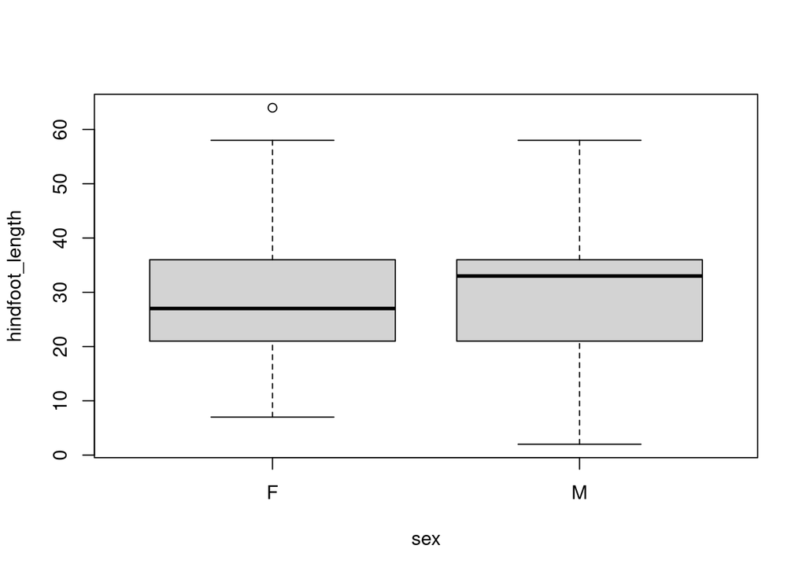

```r
plot(hindfoot_length ~ sex, data=surveys)
```

```r
t.test(hindfoot_length ~ sex, data=surveys)
```

```
##
##  Welch Two Sample t-test
##
## data:  hindfoot_length by sex
## t = -8.3733, df = 30502, p-value < 2.2e-16
## alternative hypothesis: true difference in means between group F and group M is not equal to 0
## 95 percent confidence interval:
##  -1.1246565 -0.6980042
## sample estimates:
## mean in group F mean in group M
##        28.73533        29.64666
```

```r
wilcox.test(weight ~ sex, data=surveys)
```

```
##
##  Wilcoxon rank sum test with continuity correction
##
## data:  weight by sex
## W = 109931752, p-value < 2.2e-16
## alternative hypothesis: true location shift is not equal to 0
```

How to interpret the data? Are there significant differences?

# Compare individuals of one genus

We tested for all different species together, that’s maybe not a good idea as we mixed many different genera. Let’s look at genus level.

```r
t.test(hindfoot_length ~ sex, data=surveys[surveys$genus=="Perognathus", ])
```

```
##
##  Welch Two Sample t-test
##
## data:  hindfoot_length by sex
## t = 0.77769, df = 1355.3, p-value = 0.4369
## alternative hypothesis: true difference in means between group F and group M is not equal to 0
## 95 percent confidence interval:
##  -0.1182158  0.2735083
## sample estimates:
## mean in group F mean in group M
##        15.83447        15.75683
```

```r
wilcox.test(hindfoot_length ~ sex, data=surveys[surveys$genus=="Perognathus", ])
```

```
##
##  Wilcoxon rank sum test with continuity correction
##
## data:  hindfoot_length by sex
## W = 273410, p-value = 0.3304
## alternative hypothesis: true location shift is not equal to 0
```

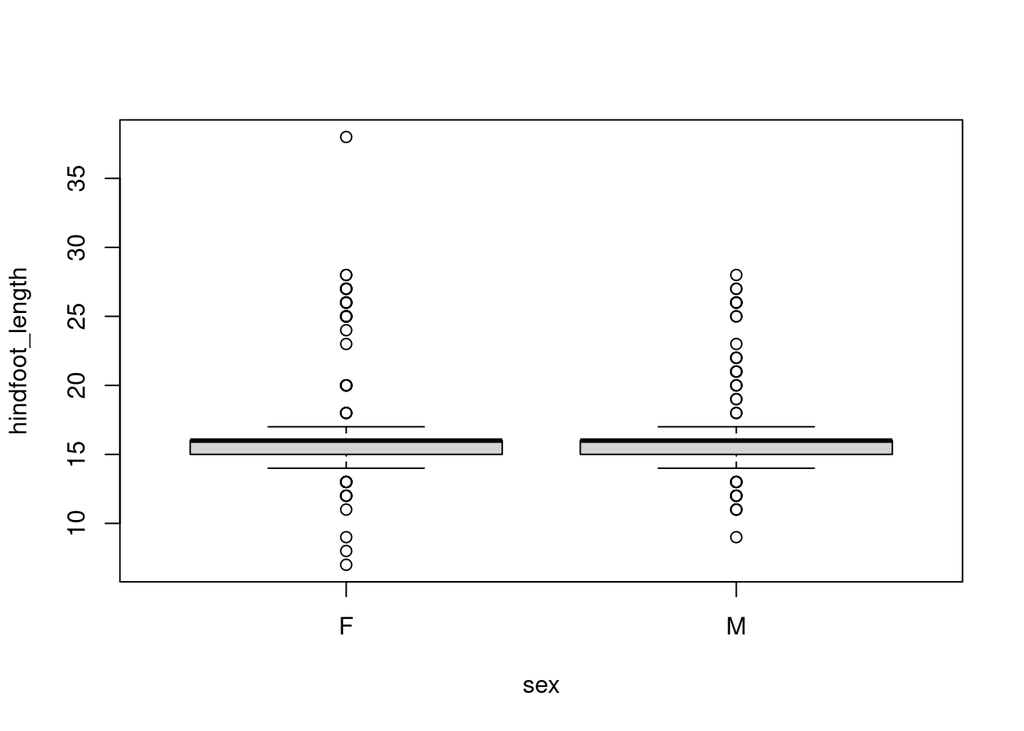

```r
plot(hindfoot_length ~ sex, data=surveys[surveys$genus=="Perognathus", ])
```

## Simulation study

We can get a bit of a feeling how these tests work if we do a simulation study. Let’s simulate some normal (Gaussian) distributed random numbers.

```r
x_samples <- 50
x_mean <- 1
x_sd <- 1
y_samples <- 50
y_mean <- 1.2
y_sd <- 1
```

Now we can create two samples x and y using these parameters:

```r
x <- rnorm(x_samples, mean = x_mean, sd = x_sd)
y <- rnorm(y_samples, mean = y_mean, sd = y_sd)
```

We can plot these distributions:

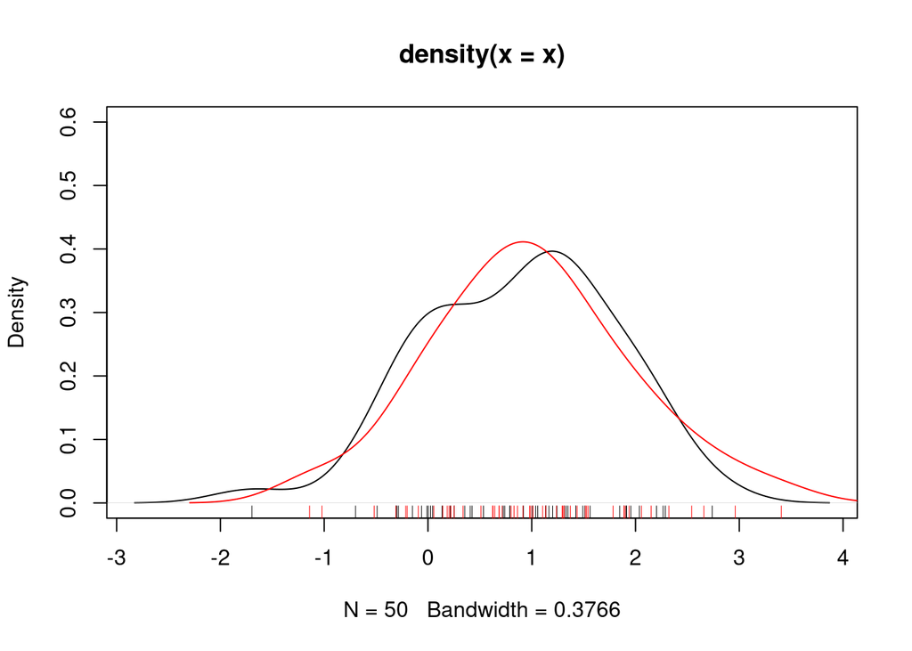

```r
plot(density(x), ylim=c(0, 0.6))
rug(x)
lines(density(y), col="red")
rug(y, col="red")
```

and test if the two groups differ significant:

```r
t.test(x, y)
```

```
##
##  Welch Two Sample t-test
##
## data:  x and y
## t = -0.56861, df = 97.692, p-value = 0.5709
## alternative hypothesis: true difference in means is not equal to 0
## 95 percent confidence interval:
##  -0.4808808  0.2666894
## sample estimates:
## mean of x mean of y
## 0.8762457 0.9833414
```

If you run the test 10 times how often does we get a significant result? What happens if you change the parameters?

## Formatting dates

A common issue that new (and experienced!) R users have is converting date and time information into a variable that is suitable for analyses. One way to store date information is to store each component of the date in a separate column. Using `str()`, we can confirm that our data frame does indeed have a separate column for day, month, and year, and that each of these columns contains integer values.

```r
str(surveys)
```

We are going to use the `ymd()` function from the package **`lubridate`** (which belongs to the **`tidyverse`**; learn more [here](https://www.tidyverse.org/)). **`lubridate`** gets installed as part as the **`tidyverse`** installation. When you load the **`tidyverse`** (`library(tidyverse)`), the core packages (the packages used in most data analyses) get loaded. **`lubridate`** however does not belong to the core tidyverse, so you have to load it explicitly with `library(lubridate)`

Start by loading the required package:

```r
library(lubridate)
```

The **`lubridate`** package has many useful functions for working with dates. These can help you extract dates from different string representations, convert between timezones, calculate time differences and more. You can find an overview of them in the [lubridate cheat sheet](https://raw.githubusercontent.com/rstudio/cheatsheets/main/lubridate.pdf).

Here we will use the function `ymd()`, which takes a vector representing year, month, and day, and converts it to a `Date` vector. `Date` is a class of data recognized by R as being a date and can be manipulated as such. The argument that the function requires is flexible, but, as a best practice, is a character vector formatted as “YYYY-MM-DD”.

Let’s create a date object and inspect the structure:

```r
my_date <- ymd("2015-01-01")
str(my_date)
```

```
##  Date[1:1], format: "2015-01-01"
```

Now let’s paste the year, month, and day separately - we get the same result:

```r
# sep indicates the character to use to separate each component
my_date <- ymd(paste("2015", "1", "1", sep = "-"))
str(my_date)
```

```
##  Date[1:1], format: "2015-01-01"
```

Now we apply this function to the surveys dataset. Create a character vector from the `year`, `month`, and `day` columns of `surveys` using `paste()`:

```r
paste(surveys$year, surveys$month, surveys$day, sep = "-")
```

```
##     [1] "1978-5-6"   "1978-8-5"   "1978-9-4"   "1979-4-29"  "1979-5-30"
##     [6] "1979-7-4"   "1979-10-25" "1979-11-17" "1980-1-16"  "1980-5-18"
##    [11] "1980-5-18"  "1981-7-8"   "1981-10-1"  "1981-11-23" "1982-1-25"
##    [16] "1982-2-24"  "1982-3-29"  "1982-3-29"  "1982-5-22"  "1982-6-28"
##    [21] "1982-6-28"  "1982-6-28"  "1982-8-16"  "1982-8-16"  "1983-6-18"
##    [26] "1983-8-16"  "1983-9-11"  "1983-9-11"  "1983-9-11"  "1983-10-16"
##    [31] "1983-10-16" "1983-11-13" "1983-11-13" "1983-12-9"  "1984-4-10"
##    [36] "1984-5-13"  "1984-5-28"  "1984-7-4"   "1984-8-26"  "1984-9-30"
##    [41] "1984-10-21" "1985-7-24"  "1985-7-24"  "1985-7-24"  "1985-8-20"
##    [46] "1985-10-13" "1985-10-13" "1985-12-8"  "1986-3-9"   "1986-5-11"
##    [51] "1986-5-11"  "1986-6-5"   "1986-6-5"   "1986-7-4"   "1986-9-7"
##    [56] "1986-9-7"   "1986-9-7"   "1986-10-5"  "1987-2-1"   "1987-3-2"
##    [61] "1987-4-6"   "1987-4-26"  "1987-4-26"  "1987-4-26"  "1987-5-28"
##    [66] "1987-5-28"  "1987-7-1"   "1987-7-1"   "1987-8-26"  "1987-9-27"
##    [71] "1987-9-27"  "1987-9-27"  "1987-10-25" "1987-10-25" "1987-11-22"
```

[output cut: 6121 more lines]

This character vector can be used as the argument for `ymd()`:

```r
ymd(paste(surveys$year, surveys$month, surveys$day, sep = "-"))
```

```
## Warning: 125 failed to parse.
```

```
##     [1] "1978-05-06" "1978-08-05" "1978-09-04" "1979-04-29" "1979-05-30"
##     [6] "1979-07-04" "1979-10-25" "1979-11-17" "1980-01-16" "1980-05-18"
##    [11] "1980-05-18" "1981-07-08" "1981-10-01" "1981-11-23" "1982-01-25"
##    [16] "1982-02-24" "1982-03-29" "1982-03-29" "1982-05-22" "1982-06-28"
##    [21] "1982-06-28" "1982-06-28" "1982-08-16" "1982-08-16" "1983-06-18"
##    [26] "1983-08-16" "1983-09-11" "1983-09-11" "1983-09-11" "1983-10-16"
##    [31] "1983-10-16" "1983-11-13" "1983-11-13" "1983-12-09" "1984-04-10"
##    [36] "1984-05-13" "1984-05-28" "1984-07-04" "1984-08-26" "1984-09-30"
##    [41] "1984-10-21" "1985-07-24" "1985-07-24" "1985-07-24" "1985-08-20"
##    [46] "1985-10-13" "1985-10-13" "1985-12-08" "1986-03-09" "1986-05-11"
##    [51] "1986-05-11" "1986-06-05" "1986-06-05" "1986-07-04" "1986-09-07"
##    [56] "1986-09-07" "1986-09-07" "1986-10-05" "1987-02-01" "1987-03-02"
##    [61] "1987-04-06" "1987-04-26" "1987-04-26" "1987-04-26" "1987-05-28"
##    [66] "1987-05-28" "1987-07-01" "1987-07-01" "1987-08-26" "1987-09-27"
##    [71] "1987-09-27" "1987-09-27" "1987-10-25" "1987-10-25" "1987-11-22"
```

[output cut: 6121 more lines]

There is a warning telling us that some dates could not be parsed (understood) by the `ymd()` function. For these dates, the function has returned `NA`, which means they are treated as missing values. We will deal with this problem later, but first we add the resulting `Date` vector to the `surveys` data frame as a new column called `date`:

```r
surveys$date <- ymd(paste(surveys$year, surveys$month, surveys$day, sep = "-"))
```

```
## Warning: 125 failed to parse.
```

```r
str(surveys) # notice the new column, with 'date' as the class
```

```
## tibble [30,676 × 14] (S3: tbl_df/tbl/data.frame)
##  $ record_id      : num [1:30676] 845 1164 1261 1756 1818 ...
##  $ month          : num [1:30676] 5 8 9 4 5 7 10 11 1 5 ...
##  $ day            : num [1:30676] 6 5 4 29 30 4 25 17 16 18 ...
##  $ year           : num [1:30676] 1978 1978 1978 1979 1979 ...
##  $ plot_id        : num [1:30676] 2 2 2 2 2 2 2 2 2 2 ...
##  $ species_id     : chr [1:30676] "NL" "NL" "NL" "NL" ...
##  $ sex            : Factor w/ 2 levels "F","M": 2 2 2 2 2 2 1 1 1 1 ...
##  $ hindfoot_length: num [1:30676] 32 34 32 33 32 32 33 30 33 31 ...
##  $ weight         : num [1:30676] 204 199 197 166 184 206 274 186 184 87 ...
##  $ genus          : Factor w/ 9 levels "Baiomys","Chaetodipus",..: 4 4 4 4 4 4 4 4 4 4 ...
##  $ species        : Factor w/ 21 levels "albigula","baileyi",..: 1 1 1 1 1 1 1 1 1 1 ...
##  $ taxa           : Factor w/ 1 level "Rodent": 1 1 1 1 1 1 1 1 1 1 ...
##  $ plot_type      : chr [1:30676] "Control" "Control" "Control" "Control" ...
##  $ date           : Date[1:30676], format: "1978-05-06" "1978-08-05" ...
##  - attr(*, "na.action")= 'omit' Named int [1:4110] 1 2 3 4 5 6 7 8 9 10 ...
##   ..- attr(*, "names")= chr [1:4110] "1" "2" "3" "4" ...
```

Let’s make sure everything worked correctly. One way to inspect the new column is to use `summary()`:

```r
summary(surveys$date)
```

```
##         Min.      1st Qu.       Median         Mean      3rd Qu.         Max.
## "1977-08-19" "1985-01-19" "1991-04-19" "1991-06-12" "1997-10-25" "2002-12-31"
##         NA's
##        "125"
```

Let’s investigate why some dates could not be parsed.

We can use the functions we saw previously to deal with missing data to identify the rows in our data frame that are failing. If we combine them with what we learned about subsetting data frames earlier, we can extract the columns “year,”month”, “day” from the records that have `NA` in our new column `date`. We will also use `head()` so we don’t clutter the output:

```r
missing_dates <- surveys[is.na(surveys$date), c("year", "month", "day")]

head(missing_dates)
```

```
## # A tibble: 6 × 3
##    year month   day
##   <dbl> <dbl> <dbl>
## 1  2000     9    31
## 2  2000     4    31
## 3  2000     4    31
## 4  2000     4    31
## 5  2000     4    31
## 6  2000     9    31
```

Why did these dates fail to parse? If you had to use these data for your analyses, how would you deal with this situation?

The answer is because the dates provided as input for the `ymd()` function do not actually exist. If we refer to the output we got above, September and April only have 30 days, not 31 days as it is specified in our dataset.

There are several ways you could deal with situation:

- If you have access to the raw data (e.g., field sheets) or supporting information (e.g., field trip reports/logs), check them and ensure the electronic database matches the information in the original data source.
- If you are able to contact the person responsible for collecting the data, you could refer to them and ask for clarification.
- You could also check the rest of the dataset for clues about the correct value for the erroneous dates.
- If your project has guidelines on how to correct this sort of errors, refer to them and apply any recommendations.
- If it is not possible to ascertain the correct value for these observations, you may want to leave them as missing data.

Regardless of the option you choose, it is important that you document the error and the corrections (if any) that you apply to your data.